# Student Performance Analysis

Wenxin Zhong

30 January, 2022

# Abstract

> Statistical learning methods were applied to student performance data in order to test attributions of student’s achievement. A variety of learning techniques were explored and validated. Simple methods like logistic regression show promise, especially given their computational efficiency at test time.

# Introduction

Parents and educators are always concerned with their children’s performance at school since the school’s performance is related to children’s development in the long run. Children’s grade at school is an important aspect to show children’s performance because the grade is based on how much effort the student put into and their willingness to learn new things. Also, a good grade can motivate the children to build confidence. For this reason, children’s grade is a significant aspect when research children’s performance.

From all the courses the children learned at school, the grade of math is especially a big concern for many parents because Mathematics grades can show the understanding, computing, applying, reasoning and engaging ability of a child. These five features are also interdependent with each other. We are also interested in mathematics performance because students throughout the world take math courses, we think studying on the math grade is more representative and meaningful to understand students’ performance.

# Method

## Data

The dataset is found on UCI Machine Learning [^1] and is gathered by Paulo Cortez from the University of Minho, GuimarÃ£es, Portugal. This dataset contains 33 attributes, including student’s grade(G1 for the first period, G2 for the second period, G3 for the final grade), demographic, social and many school-related features. The data was collected using school reports and questionnaires.

Some exploratory data analysis can be found in the appendix.

## Modeling

In order to detect the students’ achievement, several classification strategies were explored. Both multiclass models and binary models were considered into use. we use following modeling strategies:

- k-Nearest Neighbour model, through the use of `caret` package.
- Random Forests, though the use of the `ranger` package. (The `ranger` packages implements random forests, as well as extremely randomized trees. The difference is considered a tuning parameter.)

-Boosted Model, using training data from “caret” package, and Stochastic Gradient Boosting through the use of the gbm method.

-logistic regression with a lasso regression, we created a matrix for use with cv.glmnet() function to fit a logistic regression with alpha=1.

-logistic regression with a ridge regression, we created a matrix for use with cv.glmnet() function to fit a logistic regression with alpha=0.

### Evaluation

Models were ultimately evaluated based on their ability to predict the students’ math grade level. Compared with multiclass models and binary models, all binary models have higher accuracy than multiclass models. Thus, binary models is better than multiclass models in evaluating the students’ math grade in real life.

### Multiclass Classification

```r
cv_multi = trainControl(method = "cv", number = 10)
```

```r
#knn model for multiclass classification
set.seed(42)
fit_multiclass_knn = train(
  G3_letter ~ . - G3 - G3_bin,
  data = stumath_trn,
  method = "knn",
  trControl = trainControl(method = "cv", number = 10)
)
```

```r
# random forest model for multiclass classification
set.seed(42)
fit_multiclass_rf = train(
  G3_letter ~ . - G3 - G3_bin,
  data = stumath_trn,
  method = "ranger",
  trControl = trainControl(method = "cv", number = 10),
  verbose = FALSE
)
```

## Binary Classification

```r
#boosted model for binary classification
set.seed(42)
fit_bin_gbm = train(
  form = G3_bin ~ . - G3_letter - G3,
  data = stumath_trn,
  method = "gbm",
  trControl = trainControl(
    method = "cv",
    number = 10,
    classProbs = TRUE,
    summaryFunction = twoClassSummary
  ),
  metric = "Sens",
  verbose = FALSE
)
```

```r
#random forest for binary classification
set.seed(42)
fit_bin_rf = randomForest(
  G3_bin ~ . - G3 - G3_letter,
  data = stumath_trn,
  mtry = 10,
  ntree = 200
)
```

```r
#logistic regression with a lasso regression penalty
set.seed(42)
fit_glmnet_lasso = cv.glmnet(
  math_trn_x_bin,
  stumath_trn$G3_bin,
  nfolds = 10,
  alpha = 1 ,
  family = "binomial"
)
```

```r
#logistic regression with a ridge regression penalty
set.seed(42)
fit_glmnet_ridge = cv.glmnet(
  math_trn_x_bin,
  stumath_trn$G3_bin,
  nfolds = 10,
  alpha = 0 ,
  family = "binomial"
)
```

# Result

Table: **Multiclass KNN Model**, Cross-Validated Binary Predictions versus Multiclass Response, Percent

|  | Final Grade Letter A | Final Grade Letter B | Final Grade Letter C | Final Grade Letter D | Final Grade Letter E | Final Grade Letter F |
| --- | --- | --- | --- | --- | --- | --- |
| Predict: Fail | 0.000 | 0.000 | 0.000 | 0.508 | 4.061 | 18.782 |
| Predict: Pass | 4.569 | 6.599 | 16.751 | 18.274 | 21.827 | 8.629 |

Table: **Multiclass Random Forest**, Cross-Validated Binary Predictions versus Multiclass Response, Percent

|  | Final Grade Letter A | Final Grade Letter B | Final Grade Letter C | Final Grade Letter D | Final Grade Letter E | Final Grade Letter F |
| --- | --- | --- | --- | --- | --- | --- |
| Predict: Fail | 0.000 | 0.000 | 0.000 | 0.000 | 5.076 | 23.858 |
| Predict: Pass | 4.569 | 6.599 | 16.751 | 18.782 | 20.812 | 3.553 |

## Cross-Validation

Table: **Binary Logistic Regression**, Cross-Validated Binary Predictions versus Multiclass Response, Percent

[output not shown]

## Accuracy Comparison

Table:Accuracy Comparison

| Model | Accuracy |
| --- | --- |
| KNN Classification Model | 0.631 |
| Random Forest Classification Model | 0.778 |
| GBM Binary Model | 0.914 |
| Random Forest Binary Model | 0.919 |
| Logistic Regression With a Lasso Regression Penalty | 0.919 |
| Logistic Regression With a Ridge Regression Penalty | 0.884 |

# Discussion

The results show promise, the accuracy for binary model using `randomForest` method is high and shows its reliability. The below table also summarizes the results of the chosen model on a held-out test dataset. The output valus are still ideal, which means our models can be applicable to reality.

Table: Test Results, **Binary RandomForest Model**, Percent

[output not shown]

Also, the model shows that students’ math grade is highly related to factors we used, including school, sex, age mother and father’s education, studytime, number of past class failures,extra educational support,family educational support and so on, and such many variables is one reason why our accuracy is high. In real life, there are many things can affect students’ achievement at school, and that is the same as what we analysis in our project. So, it is not an easy thing if one want to improve his/her performance at school, because he/she need to put more efforts in study and change his/hers study habits.

Despite the somewhat promising result, some serious issues occurred with this dataset. Firstly, there are problems with the sampling procedure used to collect the data. More data from school Gabriel Pereira than Mousinho da Silveira was collected in the dataset. This issue would be problematic since there are definitely existing confounders between different schools, such as teaching style or school type (public or private). In addition, the data was collected specifically from Portugal. Using the model outside the nation might also result in terrible extrapolation.

Additional analysis based on updated data collection is recommended.

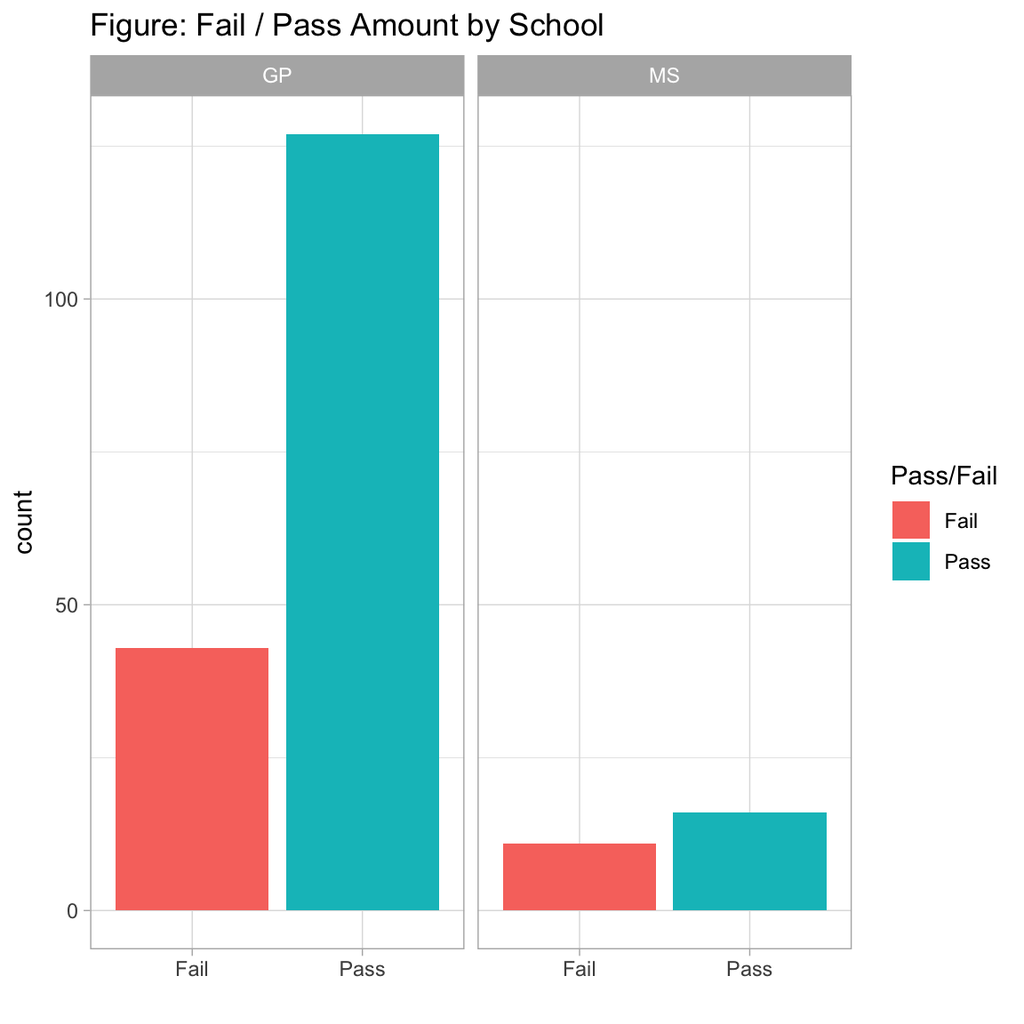

# Appendix

## Data Dictionary

- `school` - student’s school (binary: ‘GP’ - Gabriel Pereira or ‘MS’ - Mousinho da Silveira)
- `sex` - student’s sex (binary: ‘F’ - female or ‘M’ - male)
- `age` - student’s age (numeric: from 15 to 22)
- `address` - student’s home address type (binary: ‘U’ - urban or ‘R’ - rural)
- `Medu` - mother’s education (numeric: 0 - none, 1 - primary education (4th grade), 2 – 5th to 9th grade, 3 – secondary education or 4 – higher education)
- `Fedu` - father’s education (numeric: 0 - none, 1 - primary education (4th grade), 2 – 5th to 9th grade, 3 – secondary education or 4 – higher education)
- `traveltime` - home to school travel time (numeric: 1 - <15 min., 2 - 15 to 30 min., 3 - 30 min. to 1 hour, or 4 - >1 hour)
- `studytime` - weekly study time (numeric: 1 - <2 hours, 2 - 2 to 5 hours, 3 - 5 to 10 hours, or 4 - >10 hours)
- `failures` - number of past class failures (numeric: n if 1<=n<3, else 4)
- `schoolsup` - extra educational support (binary: yes or no)
- `famsup` - family educational support (binary: yes or no)
- `paid` - extra paid classes within the course subject (Math or Portuguese) (binary: yes or no)
- `activities` - extra-curricular activities (binary: yes or no)
- `nursery` - attended nursery school (binary: yes or no)
- `higher` - wants to take higher education (binary: yes or no)
- `internet` - Internet access at home (binary: yes or no)
- `romantic` - with a romantic relationship (binary: yes or no)
- `famrel` - quality of family relationships (numeric: from 1 - very bad to 5 - excellent)
- `freetime` - free time after school (numeric: from 1 - very low to 5 - very high)
- `goout` - going out with friends (numeric: from 1 - very low to 5 - very high)
- `Dalc` - workday alcohol consumption (numeric: from 1 - very low to 5 - very high)
- `Walc` - weekend alcohol consumption (numeric: from 1 - very low to 5 - very high)
- `health` - current health status (numeric: from 1 - very bad to 5 - very good)
- `absences` - number of school absences (numeric: from 0 to 93)
- `G1` - first period grade (numeric: from 0 to 20)
- `G2` - second period grade (numeric: from 0 to 20)
- `G3` - final grade (numeric: from 0 to 20, output target)

See the documentation for the `ucidata` package or the UCI website for additional documentation.

## EDA

Table: Statistics by Outcome, Training Data

| G3_bin | Count | Fail / Pass Amount 5th Percent | Fail / Pass Amount 1st Quantile | Fail / Pass Amount Median | Fail / Pass Amount 3rd Quantile | Fail / Pass Amount 95th Percent |
| --- | --- | --- | --- | --- | --- | --- |
| Fail | 54 | 0 | 0 | 8 | 8 | 9 |
| Pass | 143 | 10 | 11 | 13 | 15 | 18 |

[figure not shown]

## Additional Results

Table: KNN Multiclass Classification Result

| k | Accuracy | Kappa | AccuracySD | KappaSD |
| --- | --- | --- | --- | --- |
| 5 | 0.555 | 0.432 | 0.085 | 0.110 |
| 7 | 0.595 | 0.483 | 0.089 | 0.114 |
| 9 | 0.573 | 0.456 | 0.100 | 0.127 |

Table: Random Forest Multiclass Classification Result

| mtry | min.node.size | splitrule | Accuracy | Kappa | AccuracySD | KappaSD |
| --- | --- | --- | --- | --- | --- | --- |
| 2 | 1 | gini | 0.581 | 0.460 | 0.084 | 0.105 |
| 2 | 1 | extratrees | 0.532 | 0.393 | 0.125 | 0.164 |
| 13 | 1 | gini | 0.707 | 0.627 | 0.059 | 0.073 |
| 13 | 1 | extratrees | 0.670 | 0.580 | 0.059 | 0.074 |
| 25 | 1 | gini | 0.717 | 0.640 | 0.072 | 0.090 |
| 25 | 1 | extratrees | 0.701 | 0.621 | 0.047 | 0.058 |

Table: GBM Binary Classification Result

|  | shrinkage | interaction.depth | n.minobsinnode | n.trees | ROC | Sens | Spec | ROCSD | SensSD | SpecSD |
| --- | --- | --- | --- | --- | --- | --- | --- | --- | --- | --- |
| 1 | 0.1 | 1 | 10 | 50 | 0.977 | 0.850 | 0.916 | 0.026 | 0.174 | 0.065 |
| 4 | 0.1 | 2 | 10 | 50 | 0.975 | 0.830 | 0.929 | 0.027 | 0.198 | 0.067 |
| 7 | 0.1 | 3 | 10 | 50 | 0.968 | 0.833 | 0.916 | 0.035 | 0.137 | 0.065 |
| 2 | 0.1 | 1 | 10 | 100 | 0.969 | 0.833 | 0.916 | 0.038 | 0.184 | 0.065 |
| 5 | 0.1 | 2 | 10 | 100 | 0.970 | 0.857 | 0.930 | 0.032 | 0.165 | 0.058 |
| 8 | 0.1 | 3 | 10 | 100 | 0.962 | 0.820 | 0.915 | 0.038 | 0.184 | 0.074 |
| 3 | 0.1 | 1 | 10 | 150 | 0.966 | 0.800 | 0.922 | 0.037 | 0.197 | 0.063 |
| 6 | 0.1 | 2 | 10 | 150 | 0.967 | 0.820 | 0.922 | 0.035 | 0.184 | 0.063 |
| 9 | 0.1 | 3 | 10 | 150 | 0.968 | 0.837 | 0.908 | 0.033 | 0.157 | 0.083 |

Table: Logistic Regression With a Lasso Regression Penalty Summary

|  | Length | Class | Mode |
| --- | --- | --- | --- |
| lambda | 100 | -none- | numeric |
| cvm | 100 | -none- | numeric |
| cvsd | 100 | -none- | numeric |
| cvup | 100 | -none- | numeric |
| cvlo | 100 | -none- | numeric |
| nzero | 100 | -none- | numeric |
| call | 6 | -none- | call |
| name | 1 | -none- | character |
| glmnet.fit | 13 | lognet | list |
| lambda.min | 1 | -none- | numeric |
| lambda.1se | 1 | -none- | numeric |
| index | 2 | -none- | numeric |

Table: Logistic Regression With a Ridge Regression Penalty Summary

|  | Length | Class | Mode |
| --- | --- | --- | --- |
| lambda | 100 | -none- | numeric |
| cvm | 100 | -none- | numeric |
| cvsd | 100 | -none- | numeric |
| cvup | 100 | -none- | numeric |
| cvlo | 100 | -none- | numeric |
| nzero | 100 | -none- | numeric |
| call | 6 | -none- | call |
| name | 1 | -none- | character |
| glmnet.fit | 13 | lognet | list |
| lambda.min | 1 | -none- | numeric |
| lambda.1se | 1 | -none- | numeric |
| index | 2 | -none- | numeric |

[^1]: [Student Performance Data Set](https://archive.ics.uci.edu/ml/datasets/student+performance)